# Simple document

```r
library(tidyverse)
```

I’m an R Markdown document!

# Section 1

Here’s a **code chunk** that samples from a *normal distribution*: #brackets around the r say that everything after it is r code

```r
samp = rnorm(100)
length(samp)
```

```
## [1] 100
```

# Section 2:

The quotes on the in-line are on the key next to the one, it’s not an apostrophe. An apostrophe won’t work for the code.

I can take the mean of the sample, too! The mean is -0.07.

# Section 3

You can name the chunks of code within the curly brackets with the r at the beginning of the code chunks.

```r
plot_df=
  tibble(
    x=rnorm(n=1000),
    y=1+2*x+rnorm(n=1000)
  )
```

Learning assessment: Write a named code chunk that creates a dataframe comprised of: a numeric variable containing a random sample of size 500 from a normal variable with mean 1; a logical vector indicating whether each sampled value is greater than zero; and a numeric vector containing the absolute value of each element. Then, produce a histogram of the absolute value variable just created. Add an inline summary giving the median value rounded to two decimal places. What happens if you set eval = FALSE to the code chunk? What about echo = FALSE?

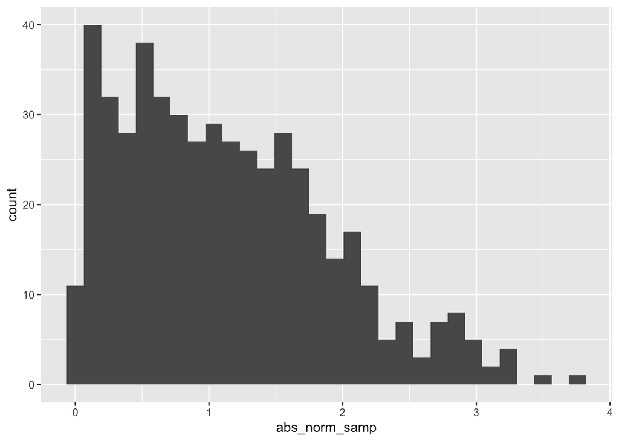

```r
la_df = tibble(
  norm_samp = rnorm(500, mean = 1),
  norm_samp_pos = norm_samp > 0,
  abs_norm_samp = abs(norm_samp)
)

ggplot(la_df, aes(x = abs_norm_samp)) + geom_histogram()
```

```r
median_samp = median(pull(la_df, norm_samp))
```